# To Leave or Not to Leave?

HR Analytics

Jeremy Dong

August 17, 2017

## Introduction

At company X, the premature exodus of some of its best and most experienced exmployees has left HR worried.

Using X’s data set, our goal is to help HR build a classifier that can accurately predict whether or not an employee leaves and correctly identify the key features influencing his/her decision.

## Data

### 1 - Tidy Data

#### Objectives

- *Read in the HR data set and convert it into a* [tidy format](https://cran.r-project.org/web/packages/tidyr/vignettes/tidy-data.html)
- *Generate training, testing, and validation sets from the tidy data*

#### Data Source

[Kaggle HR](https://www.kaggle.com/ludobenistant/hr-analytics)

#### Load Data

Read in and store HR data as a data frame called *employees*

```r
library(readr)
library(dplyr)
library(knitr)
library(kableExtra)

# build employees tidy df
employees <- read_csv("../data/hr.csv", col_types = "ddiiiiiicc") %>%
  mutate(sales = factor(sales, level = c("sales","technical","support","IT",
                                         "product_mng","marketing","RandD",
                                         "accounting","hr","management")),
         salary = factor(salary, level = c("low","medium","high"))) %>%
  rename("average_monthly_hours" = average_montly_hours)

kable(employees[1:5, 1:7], format = "html", caption = "sample of employees data") %>%
  kable_styling(bootstrap_options = c("striped", "hover"), font_size = 11, full_width = FALSE)
```

sample of employees data

| satisfaction_level | last_evaluation | number_project | average_monthly_hours | time_spend_company | Work_accident | left |
| --- | --- | --- | --- | --- | --- | --- |
| 0.38 | 0.53 | 2 | 157 | 3 | 0 | 1 |
| 0.80 | 0.86 | 5 | 262 | 6 | 0 | 1 |
| 0.11 | 0.88 | 7 | 272 | 4 | 0 | 1 |
| 0.72 | 0.87 | 5 | 223 | 5 | 0 | 1 |
| 0.37 | 0.52 | 2 | 159 | 3 | 0 | 1 |

#### Split Data

Randomly split *employees* data into 3 disjoint data sets:

1. Training Set - *60%*
   1. used for model building
2. Testing Set - *20%*
   1. used for initial testing
3. Validation Set - *20%*
   1. used for final testing + model selection

```r
library(caret)

set.seed(1)
inTrain <- createDataPartition(employees$left, p = 0.6, list = FALSE)
train <- employees[inTrain,] # training set
testing <- employees[-inTrain,]

inTest <- createDataPartition(testing$left, p = 0.5, list = FALSE)
test <- testing[inTest,] # testing set
validation <- testing[-inTest,] # validation set
```

### 2 - Exploratory Analysis

#### Objectives

- *explore features of the employees data set*
- *find relationships between features*
- *gather intuition for why employees are leaving*

#### Structure

**9 Feature Variables:**

- *satisfaction level*
  - employee satisfaction (0-1)
- *last evaluation*
  - time, measured by fraction of a year, since last evaluation (0-1)
- *number project*
  - number of projects an employee is working on
- *average monthly hours*
  - average number of hours an employee works per month
- *time spend company*
  - total number of years an employee has worked
- *work accident*
  - whether or not an employee has been in a work accident (0 or 1)
- *promotion last 5 years*
  - whether or not an employee has been promoted in the last 5 years (0 or 1)
- *sales*
  - department an employee is in
- *salary*
  - salary level an employee is in (low, medium, high)

**1 Outcome Variable:**

- *left*
  - whether or not an employee left (0 or 1)

```r
str(train)
```

```
## Classes 'tbl_df', 'tbl' and 'data.frame':    9000 obs. of  10 variables:
##  $ satisfaction_level   : num  0.38 0.11 0.41 0.1 0.92 0.89 0.45 0.11 0.84 0.41 ...
##  $ last_evaluation      : num  0.53 0.88 0.5 0.77 0.85 1 0.54 0.81 0.92 0.55 ...
##  $ number_project       : int  2 7 2 6 5 5 2 6 4 2 ...
##  $ average_monthly_hours: int  157 272 153 247 259 224 135 305 234 148 ...
##  $ time_spend_company   : int  3 4 3 4 5 5 3 4 5 3 ...
##  $ Work_accident        : int  0 0 0 0 0 0 0 0 0 0 ...
##  $ left                 : int  1 1 1 1 1 1 1 1 1 1 ...
##  $ promotion_last_5years: int  0 0 0 0 0 0 0 0 0 0 ...
##  $ sales                : Factor w/ 10 levels "sales","technical",..: 1 1 1 1 1 1 1 1 1 1 ...
##  $ salary               : Factor w/ 3 levels "low","medium",..: 1 2 1 1 1 1 1 1 1 1 ...
```

#### Feature Exploration

##### Scatterplots:

**Scatter1** depicts the relationship between *Satisfaction Level, Average Monthly Hours*, and whether or not an employee has *Left*

Observations:

- 3 Main Clusters of Employees that Left
  - **Cluster 1** - dissatisfied + working normal hours (8 hr/day)
    - AMH -> (125, 162)
    - SL -> (0.35, 0.47)
  - **Cluster 2** -> very satisfied + working long hours (12 hr/day)
    - AMH -> (216, 276)
    - SL -> (0.72, 0.93)
  - **Cluster 3** - very dissatisfied + working long hours (14 hr/day)
    - AMH -> (242, 311)
    - SL -> (0.08, 0.12)

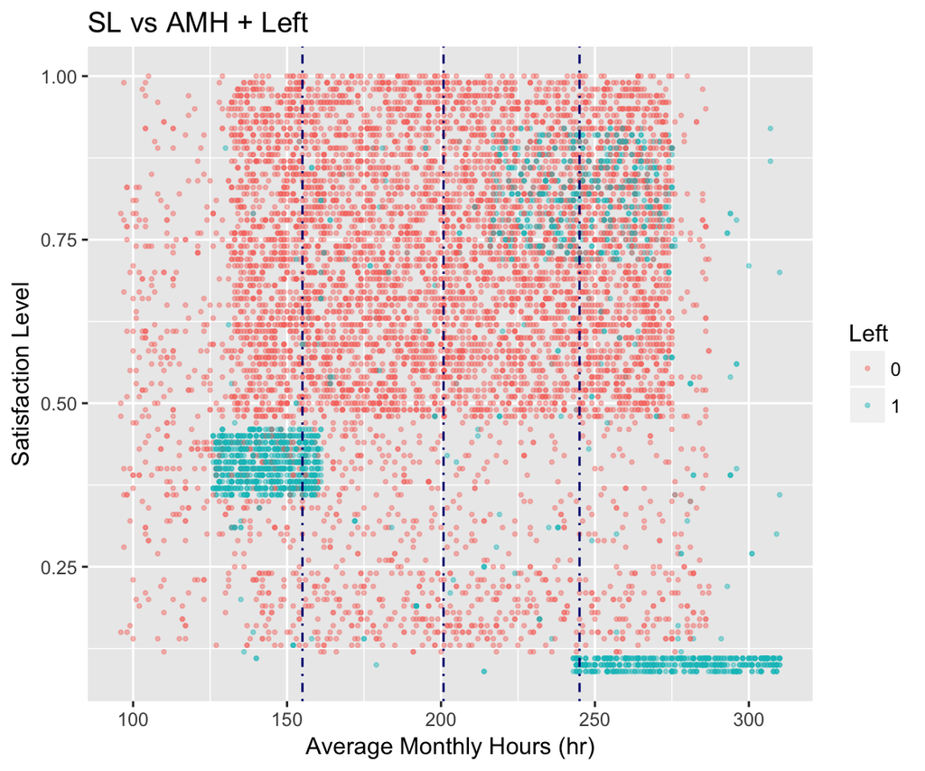

```r
library(ggplot2)
library(grid)
library(gridExtra)

# summary of average monthly hours
amh_summary <- as.numeric(summary(train$average_monthly_hours))

# scatterplot1 - AMH vs SL w/ color = left
ggplot(train, aes(x = average_monthly_hours, y = satisfaction_level)) +
  geom_point(aes(color = as.factor(left)), alpha = 0.4, size = 0.6) +
  geom_vline(xintercept = amh_summary[-c(1,3,6)], color = "navy", linetype = "dotdash") +
    labs(x = "Average Monthly Hours (hr)", y = "Satisfaction Level") +
  ggtitle("SL vs AMH + Left") +
  scale_color_discrete(name = "Left")
```

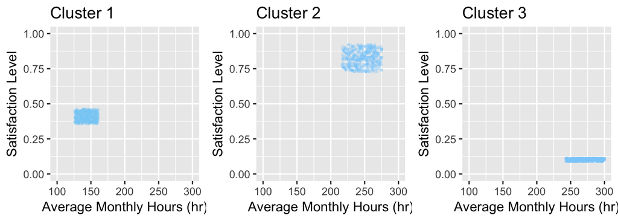

```r
# Cluster 1
cluster1 <- train %>%
  filter(satisfaction_level < 0.47, satisfaction_level > 0.35,
         average_monthly_hours < 162, average_monthly_hours > 125, left == 1)

# plot of Cluster 1
s1 <- cluster1 %>%
  ggplot(aes(x = average_monthly_hours, y = satisfaction_level)) +
  geom_point(color = "lightskyblue", alpha = 0.1, size = 0.6) +
  scale_x_continuous(limits = c(100, 300)) +
  scale_y_continuous(limits = c(0, 1)) +
  labs(x = "Average Monthly Hours (hr)", y = "Satisfaction Level") +
  ggtitle("Cluster 1")


# Cluster 2
cluster2 <- train %>%
  filter(satisfaction_level < 0.93, satisfaction_level > 0.72,
         average_monthly_hours > 216, average_monthly_hours < 276, left == 1)

# plot of Cluster 2
s2 <- cluster2 %>%
  ggplot(aes(x = average_monthly_hours, y = satisfaction_level)) +
  geom_point(color = "lightskyblue", alpha = 0.2, size = 0.6) +
  scale_x_continuous(limits = c(100, 300)) +
  scale_y_continuous(limits = c(0, 1)) +
  labs(x = "Average Monthly Hours (hr)", y = "Satisfaction Level") +
  ggtitle("Cluster 2")


# Cluster 3
cluster3 <- train %>%
  filter(satisfaction_level < 0.12,
         average_monthly_hours < 311, average_monthly_hours > 242, left == 1)

# plot of Cluster 3
s3 <- cluster3 %>%
  ggplot(aes(x = average_monthly_hours, y = satisfaction_level)) +
  geom_point(color = "lightskyblue", alpha = 0.2, size = 0.6) +
  scale_x_continuous(limits = c(100, 300)) +
  scale_y_continuous(limits = c(0, 1)) +
  labs(x = "Average Monthly Hours (hr)", y = "Satisfaction Level") +
  ggtitle("Cluster 3")

grid.arrange(s1, s2, s3, ncol = 3)
```

**Scatter2** shows how *Number of Projects* is related to whether or not an employee *Left*

Observations:

- Cluster 1 - majority have 2 projects
- Cluster 2 - majority have 4-5 projects
- Cluster 3 - majority have 6-7 projects

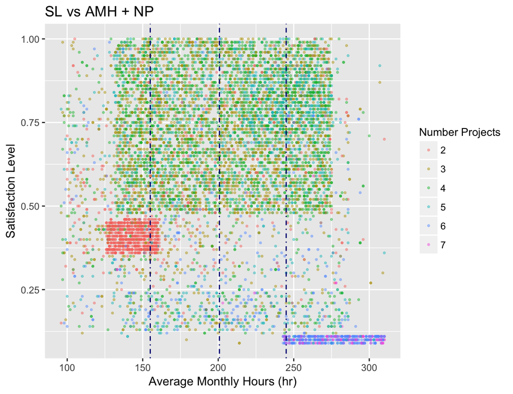

```r
# scatterplot2 - AMH vs SL w/ color = number_project
ggplot(train, aes(x = average_monthly_hours, y = satisfaction_level, color = as.factor(number_project))) +
  geom_point(alpha = 0.4, size = 0.6) +
  geom_vline(xintercept = amh_summary[-c(1,3,6)], color = "navy", linetype = "dotdash") +
  labs(x = "Average Monthly Hours (hr)", y = "Satisfaction Level") +
  ggtitle("SL vs AMH + NP") +
  scale_color_discrete(name = "Number Projects") +
  theme(legend.title = element_text(size = 10))
```

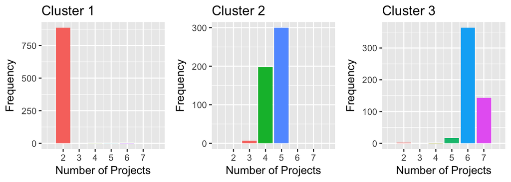

```r
# bar graph of cluster 1 - number projects
b1 <- cluster1 %>%
  group_by(number_project) %>%
  summarize(n = n()) %>%
  ggplot(aes(x = number_project, y = n, fill = as.factor(number_project))) +
  geom_bar(stat = "identity") +
  labs(x = "Number of Projects", y = "Frequency") +
  ggtitle("Cluster 1") +
  scale_x_continuous(limit = c(1, 8), breaks = 2:7) +
  theme(legend.position = "")

# bar graph of cluster 2 - number projects
b2 <- cluster2 %>%
  group_by(number_project) %>%
  summarize(n = n()) %>%
  ggplot(aes(x = number_project, y = n, fill = as.factor(number_project))) +
  geom_bar(stat = "identity") +
  labs(x = "Number of Projects", y = "Frequency") +
  ggtitle("Cluster 2") +
  scale_x_continuous(limit = c(1, 8), breaks = 2:7) +
  theme(legend.position = "")


# bar graph of cluster 3 - number projects
b3 <- cluster3 %>%
  group_by(number_project) %>%
  summarize(n = n()) %>%
  ggplot(aes(x = number_project, y = n, fill = as.factor(number_project))) +
  geom_bar(stat = "identity") +
  labs(x = "Number of Projects", y = "Frequency") +
  ggtitle("Cluster 3") +
  scale_x_continuous(limit = c(1, 8), breaks = 2:7) +
  theme(legend.position = "")

grid.arrange(b1, b2, b3, ncol = 3)
```

**Scatter3** provides insights into the employees that *Left* and the time they spent at the company:

Observations:

- Cluster 1 - majority 3rd years
- Cluster 2 - mix of 5th and 6th years
- Cluster 3 - majority 4th years

Note:

- significant increase in workload from 3rd year -> 4th year

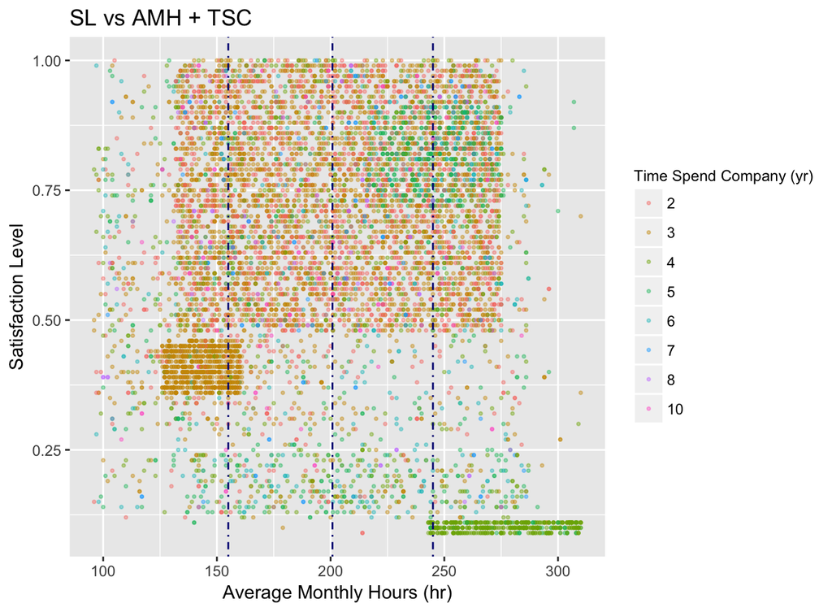

```r
# scatterplot3 - AMH vs SL w/ color = time_spend_company
ggplot(train, aes(x = average_monthly_hours, y = satisfaction_level, color = as.factor(time_spend_company))) +
  geom_point(alpha = 0.4, size = 0.6) +
  geom_vline(xintercept = amh_summary[-c(1,3,6)], color = "navy", linetype = "dotdash") +
  labs(x = "Average Monthly Hours (hr)", y = "Satisfaction Level") +
  ggtitle("SL vs AMH + TSC") +
  scale_color_discrete(name = "Time Spend Company (yr)") +
  theme(legend.title = element_text(size = 9))
```

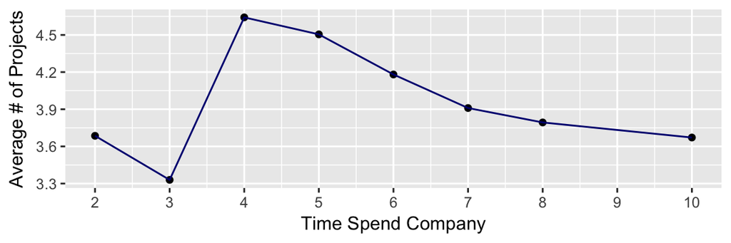

```r
# line graph of average number of projects for each year
train %>%
  group_by(time_spend_company) %>%
  summarize(avg_number_project = mean(number_project)) %>%
  ggplot(aes(x = time_spend_company, y = avg_number_project)) +
  geom_point() +
  geom_line(color = "navy") +
  scale_x_continuous(breaks = 2:10) +
  scale_y_continuous(breaks = seq(3, 5, 0.3)) +
  labs(x = "Time Spend Company", y = "Average # of Projects")
```

#### Summary

**Cluster 1**

- dissatsified (SL < 0.5) 3rd year employees who are working normal hours (8) but have little to do due to their low # of projects (2)

**Cluster 2**

- very satisfied (SL > 0.7) 5th-6th year employees who are working long hours (12) and have a nomral # of projects (4-5)

**Cluster 3**

- very dissatisfied (SL < 0.25) 4th year employees who are working very long hours (14) and have too many projects (6-7)

## Predictive Modeling

### 1 - Logistic Regression

#### Goal

Build a linear model that can accurately predict whether or not an employee leaves

#### Baseline Model

Naive Baseline: prediction model that predicts the most frequent outcome every time

Baseline Training Set Accuracy: *0.763*

- predict all 0’s (stay)

Baseline Testing Set Accuracy: *0.764*

- predict all 0’s (stay)

```r
# training set
train_baseline <- max(table(train$left) / nrow(train))

# testing set
test_baseline <- max(table(test$left) / nrow(test))
```